# Tarea 4 [Actividad grupal]: ggplot

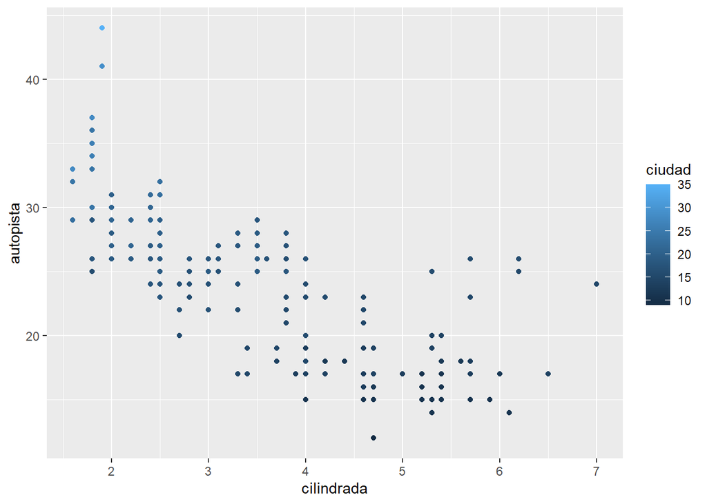

```r
  ## Se leen como color rojo porque el parametro de color se encuentra dentro del asignamiento de ejes

ggplot(millas, aes(x = cilindrada, y = autopista, colour = ciudad)) +
  geom_point()
```

Asigna una variable continua a color, size, y shape. ¿Cómo se comportan estas estéticas de manera diferente para variables categóricas y variables continuas?

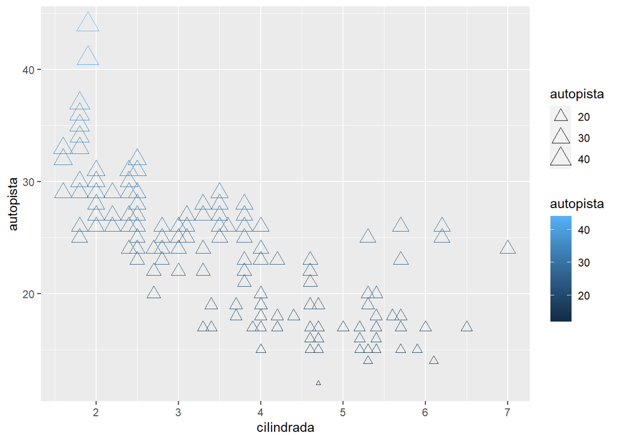

```r
  # cilindrada es una variable continua
ggplot(millas, aes(x = cilindrada, y = autopista, colour = autopista, size = autopista)) +
  geom_point(shape = 24)
```

¿Qué ocurre si asignas o mapeas la misma variable a múltiples estéticas?

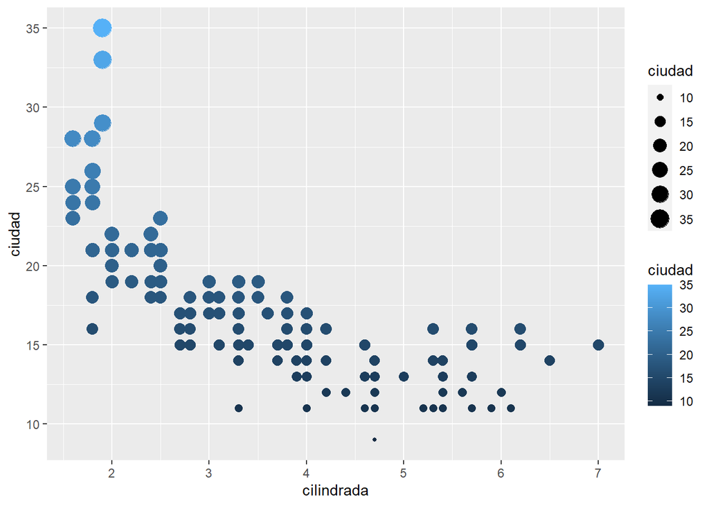

```r
ggplot(millas, aes(x = cilindrada, y = ciudad, colour = ciudad, size = ciudad)) +
  geom_point()
```

¿Qué hace la estética stroke? ¿Con qué formas trabaja? (Pista: consulta ?geom_point)

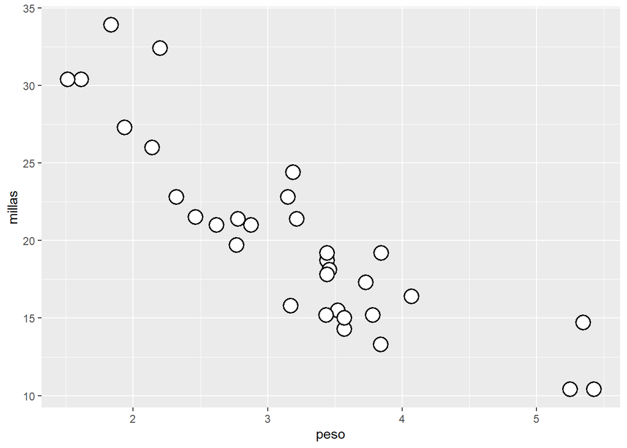

```r
ggplot(mtautos, aes(peso, millas)) +
  geom_point(shape = 21, colour = "black", fill = "white", size = 5, stroke = 1)
```

```r
  ## Modifica el grosor del borde del shape
```

¿Qué ocurre si se asigna o mapea una estética a algo diferente del nombre de una variable, como aes(color = cilindrada < 5)?

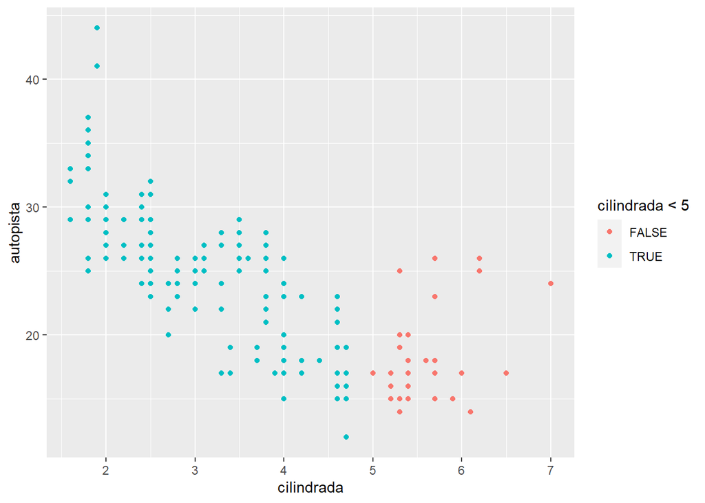

```r
ggplot(millas, aes(x = cilindrada, y = autopista, colour = cilindrada < 5)) +
  geom_point()
```

```r
 # Crea un margen en el eje x = 5 que divide en 2 colores
```